# Project: Movie Data Analysis

- Introduction
- Data Wrangling
- Exploratory Data Analysis
- Conclusions

## Introduction

> **I like to watch movies and I have some questioned that I would like to answer by the data. For my analysis, I selected TMDb movie data. This data set contains information about 10,000 movies collected from The Movie Database (TMDb), including user ratings and revenue. To begin with , I watched a lot of movies that are not popular but it has a high rating. Also, there are some movies with huge budget but they are unpopular. that's take us to my questions.**

> **What is the most factors that effect movie's popularity?**

> **Does the budget have any effect on TMDb votes ? And how votes impact the movies revenue ?**

> **What is the most popular genre of movies?**

If you are interested, Let's jump to the code!

```python
#import necessary packages
import pandas as pd
import numpy as np
import matplotlib.pyplot as plt
import seaborn as sns
%matplotlib inline
sns.set()
```

```python
# Load the data
df = pd.read_csv('tmdb.csv')
df.head(3)
```

|  | id | imdb_id | popularity | budget | revenue | original_title | cast | homepage | director | tagline | ... | overview | runtime | genres | production_companies | release_date | vote_count | vote_average | release_year | budget_adj | revenue_adj |
| --- | --- | --- | --- | --- | --- | --- | --- | --- | --- | --- | --- | --- | --- | --- | --- | --- | --- | --- | --- | --- | --- |
| 0 | 135397 | tt0369610 | 32.985763 | 150000000 | 1513528810 | Jurassic World | Chris Pratt\|Bryce Dallas Howard\|Irrfan Khan\|Vi... | http://www.jurassicworld.com/ | Colin Trevorrow | The park is open. | ... | Twenty-two years after the events of Jurassic ... | 124 | Action\|Adventure\|Science Fiction\|Thriller | Universal Studios\|Amblin Entertainment\|Legenda... | 6/9/15 | 5562 | 6.5 | 2015 | 1.379999e+08 | 1.392446e+09 |
| 1 | 76341 | tt1392190 | 28.419936 | 150000000 | 378436354 | Mad Max: Fury Road | Tom Hardy\|Charlize Theron\|Hugh Keays-Byrne\|Nic... | http://www.madmaxmovie.com/ | George Miller | What a Lovely Day. | ... | An apocalyptic story set in the furthest reach... | 120 | Action\|Adventure\|Science Fiction\|Thriller | Village Roadshow Pictures\|Kennedy Miller Produ... | 5/13/15 | 6185 | 7.1 | 2015 | 1.379999e+08 | 3.481613e+08 |
| 2 | 262500 | tt2908446 | 13.112507 | 110000000 | 295238201 | Insurgent | Shailene Woodley\|Theo James\|Kate Winslet\|Ansel... | http://www.thedivergentseries.movie/#insurgent | Robert Schwentke | One Choice Can Destroy You | ... | Beatrice Prior must confront her inner demons ... | 119 | Adventure\|Science Fiction\|Thriller | Summit Entertainment\|Mandeville Films\|Red Wago... | 3/18/15 | 2480 | 6.3 | 2015 | 1.012000e+08 | 2.716190e+08 |

3 rows × 21 columns

```python
# print summary of the data
df.info()
```

```
<class 'pandas.core.frame.DataFrame'>
RangeIndex: 10866 entries, 0 to 10865
Data columns (total 21 columns):
 #   Column                Non-Null Count  Dtype
---  ------                --------------  -----
 0   id                    10866 non-null  int64
 1   imdb_id               10856 non-null  object
 2   popularity            10866 non-null  float64
 3   budget                10866 non-null  int64
 4   revenue               10866 non-null  int64
 5   original_title        10866 non-null  object
 6   cast                  10790 non-null  object
 7   homepage              2936 non-null   object
 8   director              10822 non-null  object
 9   tagline               8042 non-null   object
 10  keywords              9373 non-null   object
 11  overview              10862 non-null  object
 12  runtime               10866 non-null  int64
 13  genres                10843 non-null  object
 14  production_companies  9836 non-null   object
 15  release_date          10866 non-null  object
 16  vote_count            10866 non-null  int64
 17  vote_average          10866 non-null  float64
 18  release_year          10866 non-null  int64
 19  budget_adj            10866 non-null  float64
 20  revenue_adj           10866 non-null  float64
dtypes: float64(4), int64(6), object(11)
memory usage: 1.3+ MB
```

```python
# to see the number of rows and columns
df.shape
```

```
(10866, 21)
```

# Data Wrangling

> **before we analyze tha data , we have to do some cleaning techniques to prepare the data for the next phase**

```python
# to see the latest recorded year
df.release_year.max()
```

```
2015
```

```python
# drop the columns that not related to the analysis
clean_data= df.drop([
        'imdb_id','cast', 'homepage', 'director', 'tagline', 'keywords',
        'overview', 'runtime','release_year', 'budget_adj',
        'revenue_adj','id','production_companies'],axis=1)
```

```python
from datetime import timedelta, date

# 'release_date' type is String , we have to convert it to 'datetime' object
clean_data['release_date'] = clean_data['release_date'].astype('datetime64[ns]')
# because Century problem I have to select date less than 2015 which is the latest recorded year
future = clean_data['release_date'] > '2016-01-01'
# using 'timedelta' to represents number of days by Century
# using 'loc' to access rows with data above 2016
clean_data.loc[future,'release_date'] -= timedelta(days=365.25*100)
```

```python
clean_data['release_date'].head()
```

```
0   2015-06-09
1   2015-05-13
2   2015-03-18
3   2015-12-15
4   2015-04-01
Name: release_date, dtype: datetime64[ns]
```

```python
# check if there any missng values
clean_data.isnull().sum()
```

```
popularity         0
budget             0
revenue            0
original_title     0
genres            23
release_date       0
vote_count         0
vote_average       0
dtype: int64
```

```python
# Since the 'genres' have categorical data and it is important feature
# Also, the number of missing values is too small for the observations
# drop NA is the best choice
clean_data.dropna(inplace=True)
```

```python
# confirm there is no missing values
clean_data.isnull().sum()
```

```
popularity        0
budget            0
revenue           0
original_title    0
genres            0
release_date      0
vote_count        0
vote_average      0
dtype: int64
```

```python
# check for duplicate rows
clean_data.duplicated().sum()
```

```
1
```

```python
# drop the duplicate rows
clean_data.drop_duplicates(inplace=True)
```

```python
# methos that retern value counts
def counts(df,x):
    return df[x].value_counts()
```

```python
# to see budget values
counts(clean_data,'budget')
```

```
0           5674
20000000     190
15000000     183
25000000     178
10000000     176
            ...
51500000       1
25500000       1
1350000        1
7920000        1
4653000        1
Name: budget, Length: 557, dtype: int64
```

```python
# to see revenue values
counts(clean_data,'revenue')
```

```
0            5993
12000000       10
10000000        8
11000000        7
6000000         6
             ...
53676580        1
617000          1
13001257        1
504050219       1
20518905        1
Name: revenue, Length: 4702, dtype: int64
```

> **As you can see above , most of budget and revenue values are zero. It is clear that these values has not been recorded. We have 10866 rows , 5993 of it has a value of '0' . replace these values with mean , will be change significantly the normal distribution of the data . Because the mean will be affected by the outliers which are zero. And, the data distribution after replacement will be skewed .**

> **On my opinion, having less data with accurate numbers is better than large data with incorrect numbers. So, dropping rows that have '0' is the best choice here.**

```python
clean_data.query('budget > 100000 and revenue > 100000 ', inplace=True)
```

```python
clean_data.head()
```

|  | popularity | budget | revenue | original_title | genres | release_date | vote_count | vote_average |
| --- | --- | --- | --- | --- | --- | --- | --- | --- |
| 0 | 32.985763 | 150000000 | 1513528810 | Jurassic World | Action\|Adventure\|Science Fiction\|Thriller | 2015-06-09 | 5562 | 6.5 |
| 1 | 28.419936 | 150000000 | 378436354 | Mad Max: Fury Road | Action\|Adventure\|Science Fiction\|Thriller | 2015-05-13 | 6185 | 7.1 |
| 2 | 13.112507 | 110000000 | 295238201 | Insurgent | Adventure\|Science Fiction\|Thriller | 2015-03-18 | 2480 | 6.3 |
| 3 | 11.173104 | 200000000 | 2068178225 | Star Wars: The Force Awakens | Action\|Adventure\|Science Fiction\|Fantasy | 2015-12-15 | 5292 | 7.5 |
| 4 | 9.335014 | 190000000 | 1506249360 | Furious 7 | Action\|Crime\|Thriller | 2015-04-01 | 2947 | 7.3 |

```python
# to see the number of rows and columns
clean_data.shape
```

```
(3728, 8)
```

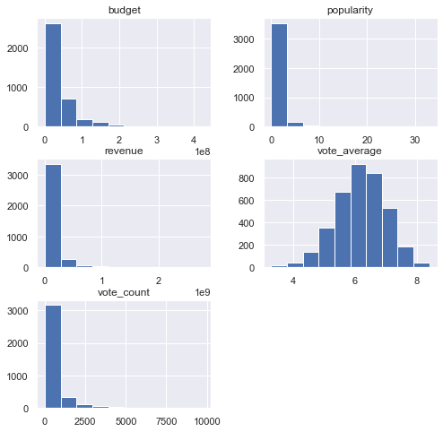

```python
# to see the distribution of data
clean_data.hist(figsize=(8,8));
```

> **Only the vote average have normal distribution. All other variables have right-skewed distribution**

# Exploratory Data Analysis

> **Now we have cleaned data, we are ready to move on to exploration**

### What is the most factors that effect movie's popularity?

```python
# to see statistical summary of 'popularity'
clean_data.popularity.describe()
```

```
count    3728.000000
mean        1.216021
std         1.492789
min         0.001117
25%         0.473170
50%         0.824917
75%         1.405960
max        32.985763
Name: popularity, dtype: float64
```

> **We can see that most data have 'popularity' in range of zero to one**

```python
# method to drow scatterplot for the given parameters
def vis_scatt(df,x,y):
    plot = sns.regplot(x=df[x], y=df[y], data=df)
    return plot
```

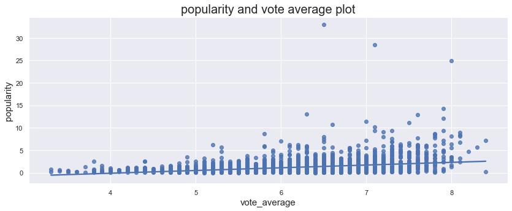

```python
# visualize the relationship between popularity and vote average

plt.figure(figsize=(14,5))
vis_scatt(clean_data,"vote_average","popularity")
plt.title('popularity and vote average plot',size=20)
plt.ylabel('popularity' , size=15)
plt.xlabel('vote_average' , size=15)
plt.show()
```

> **There is a low positive correlation between popularity and vote average**

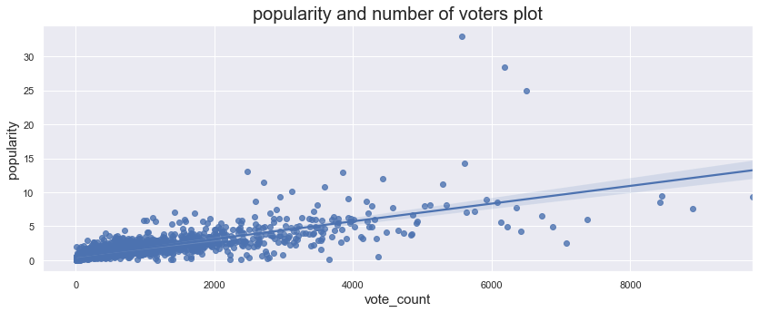

```python
# visualize the relationship between popularity and vote_count

plt.figure(figsize=(14,5))
vis_scatt(clean_data,"vote_count","popularity")
plt.title('popularity and number of voters plot',size=20)
plt.ylabel('popularity' , size=15)
plt.xlabel('vote_count' , size=15)
plt.show()
```

> **There is a highly positive correlation between popularity and number of voters**

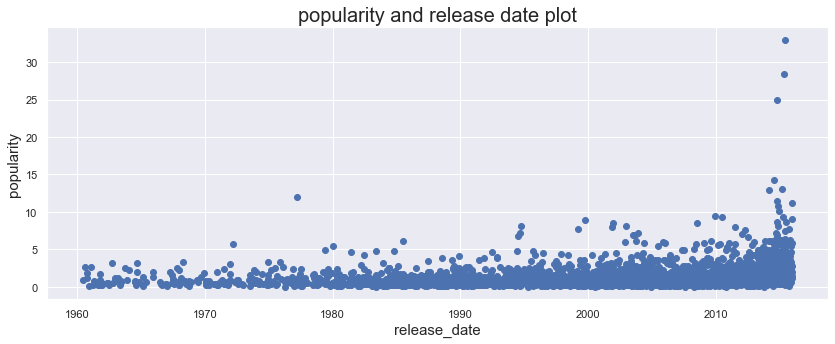

```python
# visualize the relationship between popularity and release date

plt.figure(figsize=(14,5))
plt.scatter(x = 'release_date', y= 'popularity' , data = clean_data)
plt.title('popularity and release date plot',size=20)
plt.xlabel('release_date' , size=15)
plt.ylabel('popularity' , size=15) ;
```

> **The popularity has increased after '2010'. Means that ,In the past ten years the number of users had increment, more people became interested in movies and active on TMDb. Thus made a huge impact on popularity**

### Does the budget have any effect on TMDb votes ? And how votes impact the movies revenue ?

```python
# to see statistical summary of 'vote_average'
clean_data.vote_average.describe()
```

```
count    3728.000000
mean        6.179185
std         0.788083
min         3.300000
25%         5.700000
50%         6.200000
75%         6.700000
max         8.400000
Name: vote_average, dtype: float64
```

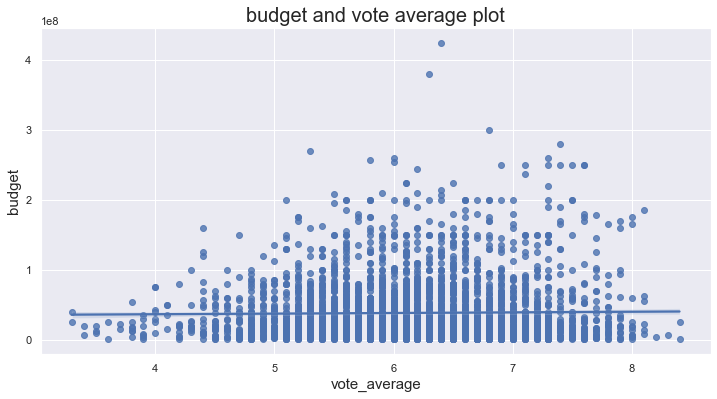

```python
# visualize the relationship

plt.figure(figsize=(12,6))
vis_scatt(clean_data,"vote_average","budget")
plt.title('budget and vote average plot',size=20)
plt.xlabel('vote_average' , size=15)
plt.ylabel('budget' , size=15) ;
```

> **There is no correlation between budget and vote average**

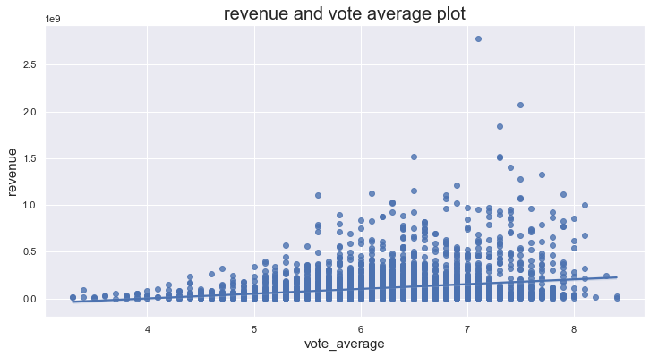

```python
# visualize the relationship

plt.figure(figsize=(12,6))
vis_scatt(clean_data,"vote_average","revenue")
plt.title('revenue and vote average plot',size=20)
plt.xlabel('vote_average' , size=15)
plt.ylabel('revenue' , size=15) ;
```

> **There is a low positive correlation between revenue and vote average**

## What is the most popular genre of movies?

```python
# creat a data frame that have the movies title and for each one of his genres in separated row

# to do that, split the string and convert it to the list to make a dataframe
# using 'original_title' as index to keep the genres for each title
# using 'stack()' to convert the columns to index
genres_title = pd.DataFrame(clean_data.genres.str.split('|').tolist(), index=clean_data.original_title).stack()

# Since each title have his own index . I will use 'reset_index()' to reset the index
genres_title = genres_title.reset_index()[[0, 'original_title']]

#rename the columns
genres_title.columns = ['genres', 'original_title']
```

```python
genres_title.head(3)
```

|  | genres | original_title |
| --- | --- | --- |
| 0 | Action | Jurassic World |
| 1 | Adventure | Jurassic World |
| 2 | Science Fiction | Jurassic World |

```python
# Since I will merge the 'genres_title' dataframe with 'clean_data'
# No need for 'genres'
clean_data.drop(['genres'],axis=1,inplace=True)
```

```python
# merge the two dataframe
movies_data = clean_data.merge(genres_title, on=['original_title'])
```

```python
movies_data.head(3)
```

|  | popularity | budget | revenue | original_title | release_date | vote_count | vote_average | genres |
| --- | --- | --- | --- | --- | --- | --- | --- | --- |
| 0 | 32.985763 | 150000000 | 1513528810 | Jurassic World | 2015-06-09 | 5562 | 6.5 | Action |
| 1 | 32.985763 | 150000000 | 1513528810 | Jurassic World | 2015-06-09 | 5562 | 6.5 | Adventure |
| 2 | 32.985763 | 150000000 | 1513528810 | Jurassic World | 2015-06-09 | 5562 | 6.5 | Science Fiction |

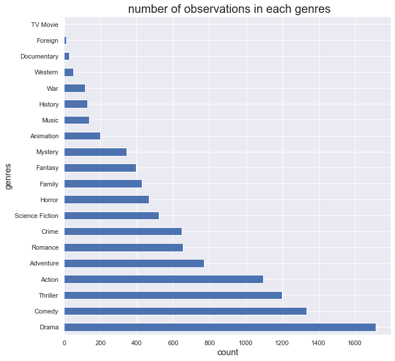

```python
# To see what is the most popular genre of moives
# plot the 'genres' to show the number of observations in each category

movies_data['genres'].value_counts().plot(kind='barh', figsize=(10,10))
plt.title(' number of observations in each genres',size=20)
plt.xlabel('count', size=15)
plt.ylabel('genres', size=15) ;
```

> **We have 3728 rows ,over 1600 of it are drama genre**

# Conclusions

#### The exploratory analysis has provided us with a lot of findings about the TMDB dataset. Let's see a summary of all them.

## Findings : movie's popularity

> **Popularity is influential metric.For both the users and TMDb, users can determine watch that movie or not based on popularity rate. For TMDb , It helps them boost search results and more advantages.**

> **So, my focus is mainly on the popularity. what is the most factors that effect movie's popularity?** **As you can see, There is a high positive correlation between popularity and number of voters. Then, vote average and release date. The most factors that effect movie's popularity is number of votes. While the number of users who votes for a movie increase , the popularity is also increased. which brings more and more votes. As result, It will add an incredible success chance for that movie.**

> **To ensure of my findings, I search in 'The movie Database API' to know how is popularity for movies calculated.** **Here is what I came with :** notice that there are some features are not included in our dataset

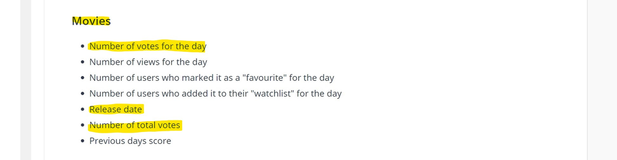

## Findings : budget , revenue and vote average

> **The plot of budget and vote average show us that there is no correlation between them . It guide us to hypothesize that not all movies with high budget end up with higher TMDb vote.** **Same with revenue. There as a small impact of vote average on revenue. observations on the most right of revenue and vote average plot gives us an evidence for that.**

## Findings : most popular genre of movies

> **Top five of popular genres are in 'Drama', 'comedy' , 'Thriller' , 'Action' and 'Adventure'.'Drama' is the most popular genre of movies .**